# Importation des données suite à une mesure avec l’Imaging-PAM

Engels Guyliann

25 mars, 2019

# Introduction

L’imaging Pam est un instrument permettant de quantifier la fluorescence émise par un organisme photosynthétique. Ce dernier permet de sélectionner différentes zones de mesures et cela est encodé par une nouvelle colonnes dans le tableau de données. Il est également envisageable d’obtenir différent paramètres monitoré (fluorescence minimale, fluorescence maximale, rendement photosynthétique,…).

```r
file <- "../../data/raw/ip001/2018-07-19-bt8-y.csv" # position
# Import data
## Importation
pam <- read_delim(file,
  ";", escape_double = FALSE, trim_ws = TRUE,
  col_types = cols(Date = col_character(),
                   Time = col_character(),
                   .default = col_number()))
DT::datatable(pam, options = list(scrollX = TRUE))
```

|  | Date | Time | No. | PAR | F1 | F2 | F3 | F4 | F5 | F6 | F7 | F8 | F9 | F10 | F11 | F12 | F13 | F14 | Fm'1 | Fm'2 | Fm'3 | Fm'4 | Fm'5 | Fm'6 | Fm'7 | Fm'8 | Fm'9 | Fm'10 | Fm'11 | … |
| --- | --- | --- | --- | --- | --- | --- | --- | --- | --- | --- | --- | --- | --- | --- | --- | --- | --- | --- | --- | --- | --- | --- | --- | --- | --- | --- | --- | --- | --- | --- |
| 1 | 19.07.18 | 06:16:38 | 1 | 2 | 0.2328 | 0.2422 | 0.2505 | 0.2069 | 0.2554 | 0.2672 | 0.274 | 0.3005 | 0.3074 | 0.2995 | 0.301 | 0.2946 | 0.2917 | 0.2593 | 0.5093 | 0.5319 | 0.551 | 0.4608 | 0.5716 | 0.5858 | 0.6054 | 0.6475 | 0.6554 | 0.6397 | 0.6436 | … |

Il est nécessaire de renommer plusieurs variables afin d’obtenir un tableau de données plus simple à analyser respectant les conventions `snake_case`

```r
## delete last colums
pam <- select(pam, - starts_with("X"))
# rename the columns
names(pam) -> t
t <-  str_replace(t, pattern = "No.", replacement =  "numb")
t <- str_replace(t, pattern = "Fm'", replacement =  "fmax_")
t <- str_replace(t, pattern = "F", replacement =  "fmin_")
t <- str_replace(t, pattern = "Y.II.", replacement =  "yield_")
t <- str_replace(t, pattern = "Y.NPQ.", replacement =  "npq_")
t <- str_replace(t, pattern = "Y.NO.", replacement =  "no_")
names(pam) <- t
# change the date
pam <- unite(pam, "date", Date, Time, sep = " ")
pam$date <- dmy_hms(pam$date)
DT::datatable(pam, options = list(scrollX = TRUE))
```

|  | date | numb | PAR | fmin_1 | fmin_2 | fmin_3 | fmin_4 | fmin_5 | fmin_6 | fmin_7 | fmin_8 | fmin_9 | fmin_10 | fmin_11 | fmin_12 | fmin_13 | fmin_14 | fmax_1 | fmax_2 | fmax_3 | fmax_4 | fmax_5 | fmax_6 | fmax_7 | fmax_8 | fmax_9 | fmax_10 | fmax_11 | fmax_12 | … |
| --- | --- | --- | --- | --- | --- | --- | --- | --- | --- | --- | --- | --- | --- | --- | --- | --- | --- | --- | --- | --- | --- | --- | --- | --- | --- | --- | --- | --- | --- | --- |
| 1 | 2018-07-19T06:16:38Z | 1 | 2 | 0.2328 | 0.2422 | 0.2505 | 0.2069 | 0.2554 | 0.2672 | 0.274 | 0.3005 | 0.3074 | 0.2995 | 0.301 | 0.2946 | 0.2917 | 0.2593 | 0.5093 | 0.5319 | 0.551 | 0.4608 | 0.5716 | 0.5858 | 0.6054 | 0.6475 | 0.6554 | 0.6397 | 0.6436 | 0.6324 | … |

Les étapes proposées ci-dessus peuvent être mis sous la forme d’une fonction pam_import()

```r
pam_import <- function(file) {
  pam <- readr::read_delim(file,
    ";",
    escape_double = FALSE, trim_ws = TRUE,
    col_types = readr::cols(
      Date = readr::col_character(),
      Time = readr::col_character(),
      .default = readr::col_number()
    )
  )
  pam$file <- file
  ## delete last colums
  pam <- dplyr::select(pam, -dplyr::starts_with("X"))
  # rename the columns
  names(pam) -> t
  t <- stringr::str_replace(t, pattern = "PAR", replacement = "par")
  t <- stringr::str_replace(t, pattern = "No.", replacement = "numb")
  t <- stringr::str_replace(t, pattern = "Fm'", replacement = "fmax_")
  t <- stringr::str_replace(t, pattern = "F", replacement = "fmin_")
  t <- stringr::str_replace(t, pattern = "Y.II.", replacement = "yield_")
  t <- stringr::str_replace(t, pattern = "Y.NPQ.", replacement = "npq_")
  t <- stringr::str_replace(t, pattern = "Y.NO.", replacement = "no_")
  names(pam) <- t
  # change the date
  pam <- tidyr::unite(pam, "date", Date, Time, sep = " ")
  pam$date <- lubridate::dmy_hms(pam$date)
  pam
}
```

Cette fonction est utilisable pour les mesures de rendement photosynthétique.

```r
test1 <- pam_import(file = "../../data/raw/ip001/2018-07-19-bt9-y.csv")
DT::datatable(test1, options = list(scrollX = TRUE))
```

|  | date | numb | par | fmin_1 | fmin_2 | fmin_3 | fmin_4 | fmin_5 | fmin_6 | fmin_7 | fmin_8 | fmin_9 | fmin_10 | fmin_11 | fmin_12 | fmin_13 | fmin_14 | fmin_15 | fmin_16 | fmax_1 | fmax_2 | fmax_3 | fmax_4 | fmax_5 | fmax_6 | fmax_7 | fmax_8 | fmax_9 | fmax_10 | … |
| --- | --- | --- | --- | --- | --- | --- | --- | --- | --- | --- | --- | --- | --- | --- | --- | --- | --- | --- | --- | --- | --- | --- | --- | --- | --- | --- | --- | --- | --- | --- |
| 1 | 2018-07-19T06:18:43Z | 1 | 2 | 0.2505 | 0.251 | 0.2672 | 0.2902 | 0.2613 | 0.301 | 0.2662 | 0.2667 | 0.2897 | 0.3015 | 0.2931 | 0.2946 | 0.3049 | 0.2623 | 0.2809 | 0.2716 | 0.5471 | 0.551 | 0.5799 | 0.623 | 0.5711 | 0.6368 | 0.5647 | 0.5667 | 0.6132 | 0.6289 | … |

Cette fonction est également utilisable pour les RLC.

```r
test2 <- pam_import(file = "../../data/raw/ip001/2018-07-20-bt9-rlc.csv")
DT::datatable(test2, options = list(scrollX = TRUE))
```

|  | date | numb | par | fmin_1 | fmin_2 | fmin_3 | fmin_4 | fmin_5 | fmin_6 | fmin_7 | fmin_8 | fmin_9 | fmin_10 | fmin_11 | fmin_12 | fmin_13 | fmin_14 | fmin_15 | fmin_16 | fmin_17 | fmax_1 | fmax_2 | fmax_3 | fmax_4 | fmax_5 | fmax_6 | fmax_7 | fmax_8 | fmax_9 | … |
| --- | --- | --- | --- | --- | --- | --- | --- | --- | --- | --- | --- | --- | --- | --- | --- | --- | --- | --- | --- | --- | --- | --- | --- | --- | --- | --- | --- | --- | --- | --- |
| 1 | 2018-07-20T07:06:44Z | 1 | 1 | 0.2108 | 0.2348 | 0.2333 | 0.2554 | 0.2319 | 0.2275 | 0.2216 | 0.2319 | 0.2505 | 0.2093 | 0.2627 | 0.2353 | 0.2564 | 0.2152 | 0.2549 | 0.2225 | 0.2549 | 0.4637 | 0.5127 | 0.5181 | 0.5613 | 0.5049 | 0.501 | 0.4863 | 0.5123 | 0.55 | … |
| 2 | 2018-07-20T07:07:05Z | 2 | 2 | 0.2157 | 0.2397 | 0.2387 | 0.2598 | 0.2363 | 0.2333 | 0.2265 | 0.2358 | 0.2544 | 0.2127 | 0.2657 | 0.2402 | 0.2593 | 0.2196 | 0.2583 | 0.227 | 0.2598 | 0.452 | 0.5005 | 0.5069 | 0.5466 | 0.4931 | 0.4912 | 0.4745 | 0.498 | 0.5353 | … |
| 3 | 2018-07-20T07:07:25Z | 3 | 52 | 0.2299 | 0.2569 | 0.2578 | 0.2848 | 0.2549 | 0.2529 | 0.2456 | 0.2642 | 0.2799 | 0.2314 | 0.2951 | 0.2632 | 0.2892 | 0.2382 | 0.2824 | 0.2461 | 0.2843 | 0.4431 | 0.4868 | 0.4936 | 0.5294 | 0.4765 | 0.4784 | 0.4627 | 0.4887 | 0.5221 | … |
| 4 | 2018-07-20T07:07:46Z | 4 | 102 | 0.2333 | 0.2613 | 0.2603 | 0.2902 | 0.2578 | 0.2549 | 0.2471 | 0.2686 | 0.2843 | 0.2343 | 0.2995 | 0.2667 | 0.2966 | 0.2397 | 0.2868 | 0.25 | 0.2902 | 0.4216 | 0.4603 | 0.4676 | 0.499 | 0.448 | 0.4515 | 0.4358 | 0.4574 | 0.4892 | … |
| 5 | 2018-07-20T07:08:06Z | 5 | 204 | 0.2559 | 0.2848 | 0.2877 | 0.3186 | 0.2819 | 0.2804 | 0.2696 | 0.2985 | 0.3152 | 0.2583 | 0.3279 | 0.2926 | 0.3265 | 0.2637 | 0.3157 | 0.275 | 0.3225 | 0.4005 | 0.4324 | 0.4422 | 0.4657 | 0.4186 | 0.424 | 0.4088 | 0.4304 | 0.4593 | … |
| 6 | 2018-07-20T07:08:26Z | 6 | 308 | 0.2588 | 0.2838 | 0.2882 | 0.3167 | 0.2799 | 0.2794 | 0.2672 | 0.2985 | 0.3132 | 0.2588 | 0.3225 | 0.2902 | 0.3225 | 0.2652 | 0.3142 | 0.2755 | 0.325 | 0.3716 | 0.398 | 0.4069 | 0.427 | 0.3848 | 0.3897 | 0.374 | 0.3926 | 0.4196 | … |
| 7 | 2018-07-20T07:08:46Z | 7 | 422 | 0.252 | 0.2735 | 0.2789 | 0.3049 | 0.2706 | 0.2706 | 0.2569 | 0.2853 | 0.3015 | 0.2515 | 0.3054 | 0.2789 | 0.3059 | 0.2564 | 0.301 | 0.2667 | 0.3127 | 0.3412 | 0.3632 | 0.3721 | 0.3882 | 0.35 | 0.3559 | 0.3392 | 0.3544 | 0.3804 | … |
| 8 | 2018-07-20T07:09:07Z | 8 | 540 | 0.2431 | 0.2618 | 0.2681 | 0.2902 | 0.2583 | 0.2588 | 0.2456 | 0.2706 | 0.2858 | 0.2412 | 0.2873 | 0.2657 | 0.2887 | 0.2456 | 0.2853 | 0.2559 | 0.298 | 0.3078 | 0.327 | 0.3363 | 0.35 | 0.3167 | 0.3216 | 0.3044 | 0.3176 | 0.3417 | … |
| 9 | 2018-07-20T07:09:27Z | 9 | 667 | 0.225 | 0.2417 | 0.248 | 0.2672 | 0.2397 | 0.2397 | 0.227 | 0.2495 | 0.2632 | 0.224 | 0.2642 | 0.2461 | 0.2652 | 0.2275 | 0.2632 | 0.2373 | 0.276 | 0.2779 | 0.2951 | 0.3044 | 0.3152 | 0.2877 | 0.2912 | 0.2745 | 0.2858 | 0.3074 | … |
| 10 | 2018-07-20T07:09:47Z | 10 | 814 | 0.2103 | 0.2275 | 0.2314 | 0.249 | 0.2245 | 0.224 | 0.2118 | 0.2319 | 0.2446 | 0.2088 | 0.2461 | 0.2294 | 0.2461 | 0.2123 | 0.2456 | 0.2221 | 0.2559 | 0.25 | 0.2672 | 0.274 | 0.2843 | 0.2603 | 0.2637 | 0.2475 | 0.2574 | 0.2765 | … |

[output cut: 3 more lines]

La mesures réalisés sur le même individu sont considérés comme des pseudos réplicats. Il est donc nécessaire d’en calculer la moyenne.

```r
t <- names(test1)
tt <- c("fmin", "fmax", "yield")
test <- vector(mode = "numeric", length = length(tt))
names(test) <- tt
for (i in seq_along(tt))
test1 %>.%
  select(., str_subset(t, tt[i])) %>.%
  apply(., MARGIN = 1, FUN = mean) -> test[[i]]
test
```

```
     fmin      fmax     yield
0.2782938 0.5901063 0.5284375
```

Ces instructions combinées avec la fonction pam_import donne la fonction pam_yield.

```r
pam_yield <- function(file, interested_var = c("fmin", "fmax", "yield")){
  require(flow)
  pam_file <- pam_import(file = file)
  i <- 1
  t <- names(pam_file)
  pam_file$aio <- sum(stringr::str_count(t, interested_var[i]))

  var_struc <- c("date", "aio", "file")
  pam_file1 <- dplyr::select(pam_file, var_struc)

  vec <- vector(mode = "numeric", length = length(interested_var))
  names(vec) <- interested_var

  for (i in seq_along(interested_var))
    pam_file %>.%
    dplyr::select(., stringr::str_subset(t, interested_var[i])) %>.%
    apply(., MARGIN = 1, FUN = mean) -> vec[i]

  df <- dplyr::bind_cols(pam_file1, dplyr::as_data_frame(t(vec)))
  df
}
```

Les deux fonctions sont placées dans un script R dédié à cela dans ce projet : R/import_yield.R

```r
source("../../R/import_yield.R")
test1 <- pam_yield(file = "../../data/raw/ip001/2018-07-19-bt9-y.csv")
```

L’utilisation de cette fonction combinée avec la dir_ls() et la fonction map_dfr() permet de renvoyer un jeu de données comprennant les valeurs moyennes pour chaque bouture.

```r
fs::dir_ls("../../data/raw/Madeleine_CSV/") %>%
  purrr::map_dfr(pam_yield) -> test
```

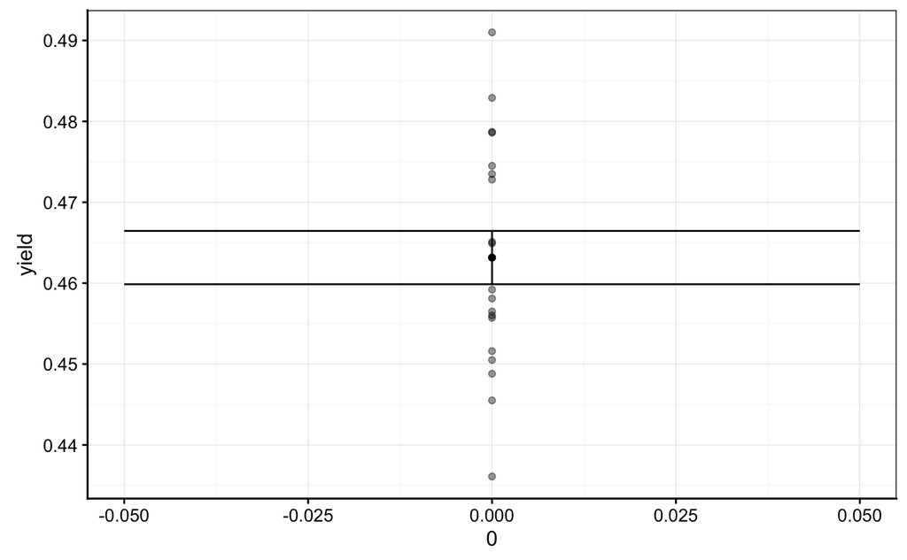

```r
chart(test, yield ~ 0) +
  geom_point(alpha = 0.4) +
  stat_summary(geom = "point", fun.y = "mean") +
  stat_summary(geom = "errorbar", width = 0.1,
    fun.data = "mean_se", fun.args = list(mult = 1))
```